# 🏏 INDIAN PREMIER LEAGUE (IPL) — DATA ANALYSIS

## Exploratory Data Analysis & Visualization Using Python

**Project By:** Harsh Pandey **Project Guide:** Mohit Sir | CETPA Infotech

**Tools & Technologies:** 🐍 Python • 📊 NumPy • 🐼 Pandas • 📈 Matplotlib • 🎨 Seaborn • 📓 Jupyter Notebook • 💻 VS Code

```python
import pandas as pd
import numpy as np
import matplotlib.pyplot as plt
import seaborn as sns

print("Libraries imported successfully!")
```

```
Libraries imported successfully!
```

```python
matches = pd.read_csv("../data/matches.csv")
deliveries = pd.read_csv("../data/deliveries.csv")

print("Matches:", matches.shape)
print("Deliveries:", deliveries.shape)
```

```
Matches: (1095, 20)
Deliveries: (260920, 17)
```

```python
matches.head()
```

|  | id | season | city | date | match_type | player_of_match | venue | team1 | team2 | toss_winner | toss_decision | winner | result | result_margin | target_runs | target_overs | super_over | method | umpire1 | umpire2 |
| --- | --- | --- | --- | --- | --- | --- | --- | --- | --- | --- | --- | --- | --- | --- | --- | --- | --- | --- | --- | --- |
| 0 | 335982 | 2007/08 | Bangalore | 2008-04-18 | League | BB McCullum | M Chinnaswamy Stadium | Royal Challengers Bangalore | Kolkata Knight Riders | Royal Challengers Bangalore | field | Kolkata Knight Riders | runs | 140.0 | 223.0 | 20.0 | N | NaN | Asad Rauf | RE Koertzen |
| 1 | 335983 | 2007/08 | Chandigarh | 2008-04-19 | League | MEK Hussey | Punjab Cricket Association Stadium, Mohali | Kings XI Punjab | Chennai Super Kings | Chennai Super Kings | bat | Chennai Super Kings | runs | 33.0 | 241.0 | 20.0 | N | NaN | MR Benson | SL Shastri |
| 2 | 335984 | 2007/08 | Delhi | 2008-04-19 | League | MF Maharoof | Feroz Shah Kotla | Delhi Daredevils | Rajasthan Royals | Rajasthan Royals | bat | Delhi Daredevils | wickets | 9.0 | 130.0 | 20.0 | N | NaN | Aleem Dar | GA Pratapkumar |
| 3 | 335985 | 2007/08 | Mumbai | 2008-04-20 | League | MV Boucher | Wankhede Stadium | Mumbai Indians | Royal Challengers Bangalore | Mumbai Indians | bat | Royal Challengers Bangalore | wickets | 5.0 | 166.0 | 20.0 | N | NaN | SJ Davis | DJ Harper |
| 4 | 335986 | 2007/08 | Kolkata | 2008-04-20 | League | DJ Hussey | Eden Gardens | Kolkata Knight Riders | Deccan Chargers | Deccan Chargers | bat | Kolkata Knight Riders | wickets | 5.0 | 111.0 | 20.0 | N | NaN | BF Bowden | K Hariharan |

```python
deliveries.head()
```

|  | match_id | inning | batting_team | bowling_team | over | ball | batter | bowler | non_striker | batsman_runs | extra_runs | total_runs | extras_type | is_wicket | player_dismissed | dismissal_kind | fielder |
| --- | --- | --- | --- | --- | --- | --- | --- | --- | --- | --- | --- | --- | --- | --- | --- | --- | --- |
| 0 | 335982 | 1 | Kolkata Knight Riders | Royal Challengers Bangalore | 0 | 1 | SC Ganguly | P Kumar | BB McCullum | 0 | 1 | 1 | legbyes | 0 | NaN | NaN | NaN |
| 1 | 335982 | 1 | Kolkata Knight Riders | Royal Challengers Bangalore | 0 | 2 | BB McCullum | P Kumar | SC Ganguly | 0 | 0 | 0 | NaN | 0 | NaN | NaN | NaN |
| 2 | 335982 | 1 | Kolkata Knight Riders | Royal Challengers Bangalore | 0 | 3 | BB McCullum | P Kumar | SC Ganguly | 0 | 1 | 1 | wides | 0 | NaN | NaN | NaN |
| 3 | 335982 | 1 | Kolkata Knight Riders | Royal Challengers Bangalore | 0 | 4 | BB McCullum | P Kumar | SC Ganguly | 0 | 0 | 0 | NaN | 0 | NaN | NaN | NaN |
| 4 | 335982 | 1 | Kolkata Knight Riders | Royal Challengers Bangalore | 0 | 5 | BB McCullum | P Kumar | SC Ganguly | 0 | 0 | 0 | NaN | 0 | NaN | NaN | NaN |

```python
matches.info()
```

```
<class 'pandas.DataFrame'>
RangeIndex: 1095 entries, 0 to 1094
Data columns (total 20 columns):
 #   Column           Non-Null Count  Dtype
---  ------           --------------  -----
 0   id               1095 non-null   int64
 1   season           1095 non-null   str
 2   city             1044 non-null   str
 3   date             1095 non-null   str
 4   match_type       1095 non-null   str
 5   player_of_match  1090 non-null   str
 6   venue            1095 non-null   str
 7   team1            1095 non-null   str
 8   team2            1095 non-null   str
 9   toss_winner      1095 non-null   str
 10  toss_decision    1095 non-null   str
 11  winner           1090 non-null   str
 12  result           1095 non-null   str
 13  result_margin    1076 non-null   float64
 14  target_runs      1092 non-null   float64
 15  target_overs     1092 non-null   float64
 16  super_over       1095 non-null   str
 17  method           21 non-null     str
 18  umpire1          1095 non-null   str
 19  umpire2          1095 non-null   str
dtypes: float64(3), int64(1), str(16)
memory usage: 171.2 KB
```

```python
matches.shape
deliveries.shape
```

```
(260920, 17)
```

```python
print("MATCHES COLUMNS:")
print(matches.columns.tolist())

print("\nDELIVERIES COLUMNS:")
print(deliveries.columns.tolist())
```

```
MATCHES COLUMNS:
['id', 'season', 'city', 'date', 'match_type', 'player_of_match', 'venue', 'team1', 'team2', 'toss_winner', 'toss_decision', 'winner', 'result', 'result_margin', 'target_runs', 'target_overs', 'super_over', 'method', 'umpire1', 'umpire2']

DELIVERIES COLUMNS:
['match_id', 'inning', 'batting_team', 'bowling_team', 'over', 'ball', 'batter', 'bowler', 'non_striker', 'batsman_runs', 'extra_runs', 'total_runs', 'extras_type', 'is_wicket', 'player_dismissed', 'dismissal_kind', 'fielder']
```

```python
matches.info()
```

```
<class 'pandas.DataFrame'>
RangeIndex: 1095 entries, 0 to 1094
Data columns (total 20 columns):
 #   Column           Non-Null Count  Dtype
---  ------           --------------  -----
 0   id               1095 non-null   int64
 1   season           1095 non-null   str
 2   city             1044 non-null   str
 3   date             1095 non-null   str
 4   match_type       1095 non-null   str
 5   player_of_match  1090 non-null   str
 6   venue            1095 non-null   str
 7   team1            1095 non-null   str
 8   team2            1095 non-null   str
 9   toss_winner      1095 non-null   str
 10  toss_decision    1095 non-null   str
 11  winner           1090 non-null   str
 12  result           1095 non-null   str
 13  result_margin    1076 non-null   float64
 14  target_runs      1092 non-null   float64
 15  target_overs     1092 non-null   float64
 16  super_over       1095 non-null   str
 17  method           21 non-null     str
 18  umpire1          1095 non-null   str
 19  umpire2          1095 non-null   str
dtypes: float64(3), int64(1), str(16)
memory usage: 171.2 KB
```

```python
print("Missing Values in Matches:")
print(matches.isnull().sum())
```

```
Missing Values in Matches:
id                    0
season                0
city                 51
date                  0
match_type            0
player_of_match       5
venue                 0
team1                 0
team2                 0
toss_winner           0
toss_decision         0
winner                5
result                0
result_margin        19
target_runs           3
target_overs          3
super_over            0
method             1074
umpire1               0
umpire2               0
dtype: int64
```

```python
print("Missing Values in Deliveries:")
print(deliveries.isnull().sum())
```

```
Missing Values in Deliveries:
```

```
match_id                 0
inning                   0
batting_team             0
bowling_team             0
over                     0
ball                     0
batter                   0
bowler                   0
non_striker              0
batsman_runs             0
extra_runs               0
total_runs               0
extras_type         246795
is_wicket                0
player_dismissed    247970
dismissal_kind      247970
fielder             251566
dtype: int64
```

```python
print("Duplicate rows in Matches:", matches.duplicated().sum())

print("Duplicate rows in Deliveries:", deliveries.duplicated().sum())
```

```
Duplicate rows in Matches: 0
```

```
Duplicate rows in Deliveries: 0
```

```python
matches.isnull().sum()
```

```
id                    0
season                0
city                 51
date                  0
match_type            0
player_of_match       5
venue                 0
team1                 0
team2                 0
toss_winner           0
toss_decision         0
winner                5
result                0
result_margin        19
target_runs           3
target_overs          3
super_over            0
method             1074
umpire1               0
umpire2               0
dtype: int64
```

```python
matches_clean = matches.copy()
deliveries_clean = deliveries.copy()

print("Copies created successfully!")
```

```
Copies created successfully!
```

```python
df = matches_clean.copy()
print('df initialized from matches_clean')
```

```
df initialized from matches_clean
```

```python
matches_clean.drop_duplicates(inplace=True)
deliveries_clean.drop_duplicates(inplace=True)

print("Duplicate rows removed!")
```

```
Duplicate rows removed!
```

```python
matches_clean.drop_duplicates(inplace=True)
deliveries_clean.drop_duplicates(inplace=True)

print("Duplicate rows removed!")
```

```
Duplicate rows removed!
```

```python
matches_clean.isnull().sum()
```

```
id                    0
season                0
city                 51
date                  0
match_type            0
player_of_match       5
venue                 0
team1                 0
team2                 0
toss_winner           0
toss_decision         0
winner                5
result                0
result_margin        19
target_runs           3
target_overs          3
super_over            0
method             1074
umpire1               0
umpire2               0
dtype: int64
```

```python
print(matches_clean.columns.tolist())
```

```
['id', 'season', 'city', 'date', 'match_type', 'player_of_match', 'venue', 'team1', 'team2', 'toss_winner', 'toss_decision', 'winner', 'result', 'result_margin', 'target_runs', 'target_overs', 'super_over', 'method', 'umpire1', 'umpire2']
```

```python
matches_clean["date"] = pd.to_datetime(
    matches_clean["date"],
    errors="coerce"
)
```

```python
matches_clean["date"].head()
```

```
0   2008-04-18
1   2008-04-19
2   2008-04-19
3   2008-04-20
4   2008-04-20
Name: date, dtype: datetime64[us]
```

```python
matches_clean.dtypes
```

```
id                          int64
season                        str
city                          str
date               datetime64[us]
match_type                    str
player_of_match               str
venue                         str
team1                         str
team2                         str
toss_winner                   str
toss_decision                 str
winner                        str
result                        str
result_margin             float64
target_runs               float64
target_overs              float64
super_over                    str
method                        str
umpire1                       str
umpire2                       str
dtype: object
```

```python
deliveries_clean.dtypes
```

```
match_id            int64
inning              int64
batting_team          str
bowling_team          str
over                int64
ball                int64
batter                str
bowler                str
non_striker           str
batsman_runs        int64
extra_runs          int64
total_runs          int64
extras_type           str
is_wicket           int64
player_dismissed      str
dismissal_kind        str
fielder               str
dtype: object
```

```python
print(matches_clean["team1"].unique())
```

```
<StringArray>
['Royal Challengers Bangalore',             'Kings XI Punjab',
            'Delhi Daredevils',              'Mumbai Indians',
       'Kolkata Knight Riders',            'Rajasthan Royals',
             'Deccan Chargers',         'Chennai Super Kings',
        'Kochi Tuskers Kerala',               'Pune Warriors',
         'Sunrisers Hyderabad',               'Gujarat Lions',
     'Rising Pune Supergiants',      'Rising Pune Supergiant',
              'Delhi Capitals',                'Punjab Kings',
        'Lucknow Super Giants',              'Gujarat Titans',
 'Royal Challengers Bengaluru']
Length: 19, dtype: str
```

```python
print(matches_clean["team1"].unique())
```

```
<StringArray>
['Royal Challengers Bangalore',             'Kings XI Punjab',
            'Delhi Daredevils',              'Mumbai Indians',
       'Kolkata Knight Riders',            'Rajasthan Royals',
             'Deccan Chargers',         'Chennai Super Kings',
        'Kochi Tuskers Kerala',               'Pune Warriors',
         'Sunrisers Hyderabad',               'Gujarat Lions',
     'Rising Pune Supergiants',      'Rising Pune Supergiant',
              'Delhi Capitals',                'Punjab Kings',
        'Lucknow Super Giants',              'Gujarat Titans',
 'Royal Challengers Bengaluru']
Length: 19, dtype: str
```

```python
total_matches = matches_clean.shape[0]

print("Total IPL Matches:", total_matches)
```

```
Total IPL Matches: 1095
```

```python
print(matches_clean["season"].unique())
```

```
<StringArray>
['2007/08',    '2009', '2009/10',    '2011',    '2012',    '2013',    '2014',
    '2015',    '2016',    '2017',    '2018',    '2019', '2020/21',    '2021',
    '2022',    '2023',    '2024']
Length: 17, dtype: str
```

```python
team_wins = matches_clean["winner"].value_counts()

print(team_wins)
```

```
winner
Mumbai Indians                 144
Chennai Super Kings            138
Kolkata Knight Riders          131
Royal Challengers Bangalore    116
Rajasthan Royals               112
Kings XI Punjab                 88
Sunrisers Hyderabad             88
Delhi Daredevils                67
Delhi Capitals                  48
Deccan Chargers                 29
Gujarat Titans                  28
Punjab Kings                    24
Lucknow Super Giants            24
Gujarat Lions                   13
Pune Warriors                   12
Rising Pune Supergiant          10
Royal Challengers Bengaluru      7
Kochi Tuskers Kerala             6
Rising Pune Supergiants          5
Name: count, dtype: int64
```

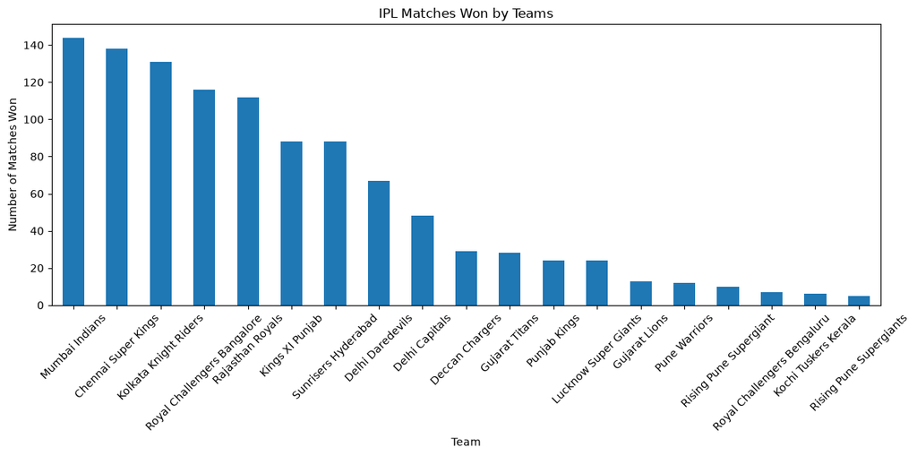

```python
plt.figure(figsize=(12, 6))

team_wins.plot(kind="bar")

plt.title("IPL Matches Won by Teams")
plt.xlabel("Team")
plt.ylabel("Number of Matches Won")

plt.xticks(rotation=45)

plt.tight_layout()

plt.show()
```

```python
print(deliveries_clean.columns.tolist())
```

```
['match_id', 'inning', 'batting_team', 'bowling_team', 'over', 'ball', 'batter', 'bowler', 'non_striker', 'batsman_runs', 'extra_runs', 'total_runs', 'extras_type', 'is_wicket', 'player_dismissed', 'dismissal_kind', 'fielder']
```

```python
batsman_column = "batter"
```

```python
batsman_column = "batsman"
```

```python
top_batsmen = (
    deliveries_clean.groupby("batter")["batsman_runs"]
    .sum()
    .sort_values(ascending=False)
    .head(10)
)

print(top_batsmen)
```

```
batter
V Kohli           8014
S Dhawan          6769
RG Sharma         6630
DA Warner         6567
SK Raina          5536
MS Dhoni          5243
AB de Villiers    5181
CH Gayle          4997
RV Uthappa        4954
KD Karthik        4843
Name: batsman_runs, dtype: int64
```

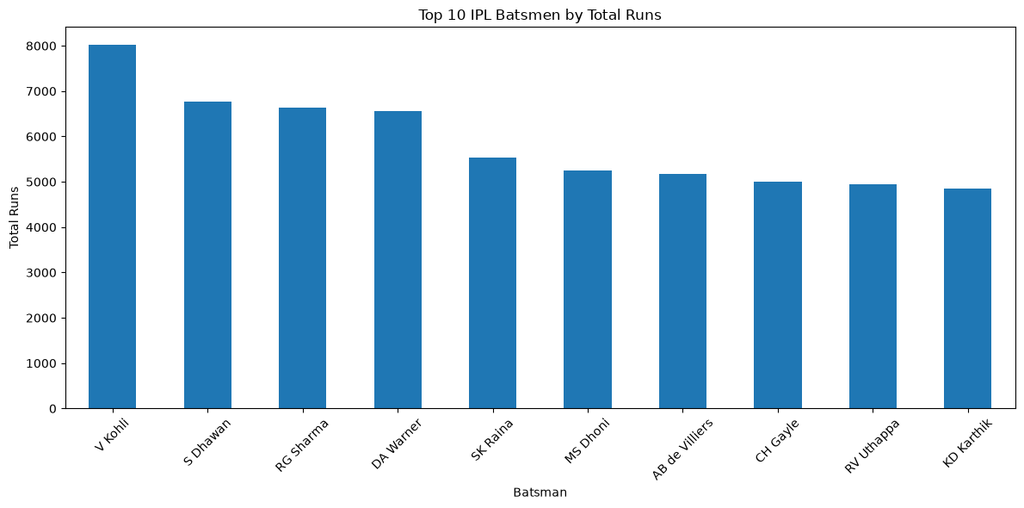

```python
plt.figure(figsize=(12, 6))

top_batsmen.plot(kind="bar")

plt.title("Top 10 IPL Batsmen by Total Runs")
plt.xlabel("Batsman")
plt.ylabel("Total Runs")

plt.xticks(rotation=45)

plt.tight_layout()

plt.show()
```

```python
print(deliveries_clean.columns.tolist())
```

```
['match_id', 'inning', 'batting_team', 'bowling_team', 'over', 'ball', 'batter', 'bowler', 'non_striker', 'batsman_runs', 'extra_runs', 'total_runs', 'extras_type', 'is_wicket', 'player_dismissed', 'dismissal_kind', 'fielder']
```

```python
deliveries_clean["dismissal_kind"].value_counts()
```

```
dismissal_kind
caught                   8063
bowled                   2212
run out                  1114
lbw                       800
caught and bowled         367
stumped                   358
retired hurt               15
hit wicket                 15
obstructing the field       3
retired out                 3
Name: count, dtype: int64
```

```python
valid_wickets = deliveries_clean[
    ~deliveries_clean["dismissal_kind"].isin(
        ["run out", "retired hurt", "obstructing the field"]
    )
]
```

```python
top_bowlers = (
    valid_wickets.groupby("bowler")
    .size()
    .sort_values(ascending=False)
    .head(10)
)

print(top_bowlers)
```

```
bowler
R Ashwin           4661
SP Narine          4126
B Kumar            4046
PP Chawla          3886
RA Jadeja          3886
YS Chahal          3620
Harbhajan Singh    3485
A Mishra           3435
DJ Bravo           3272
UT Yadav           3171
dtype: int64
```

[figure not shown]

```python
plt.figure(figsize=(12, 6))

top_bowlers.plot(kind="bar")

plt.title("Top 10 IPL Bowlers by Wickets")
plt.xlabel("Bowler")
plt.ylabel("Wickets")

plt.xticks(rotation=45)

plt.tight_layout()

plt.show()
```

```python
# Step 28: Player of the Match Analysis

player_of_match_counts = (
    matches_clean["player_of_match"]
    .dropna()
    .value_counts()
    .head(10)
)

player_of_match_counts
```

```
player_of_match
AB de Villiers    25
CH Gayle          22
RG Sharma         19
DA Warner         18
V Kohli           18
MS Dhoni          17
SR Watson         16
YK Pathan         16
RA Jadeja         16
SP Narine         15
Name: count, dtype: int64
```

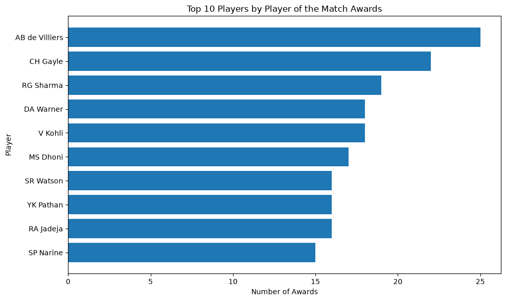

```python
import matplotlib.pyplot as plt

plt.figure(figsize=(10, 6))

plt.barh(
    player_of_match_counts.index[::-1],
    player_of_match_counts.values[::-1]
)

plt.title('Top 10 Players by Player of the Match Awards')
plt.xlabel('Number of Awards')
plt.ylabel('Player')

plt.tight_layout()
plt.show()
```

```python
pom_df = player_of_match_counts.reset_index()

pom_df.columns = ['Player', 'Player of the Match Awards']

pom_df
```

|  | Player | Player of the Match Awards |
| --- | --- | --- |
| 0 | AB de Villiers | 25 |
| 1 | CH Gayle | 22 |
| 2 | RG Sharma | 19 |
| 3 | DA Warner | 18 |
| 4 | V Kohli | 18 |
| 5 | MS Dhoni | 17 |
| 6 | SR Watson | 16 |
| 7 | YK Pathan | 16 |
| 8 | RA Jadeja | 16 |
| 9 | SP Narine | 15 |

```python
player_of_match_counts = (
    df["player_of_match"]
    .dropna()
    .value_counts()
)

top_pom_player = player_of_match_counts.idxmax()
top_pom_awards = player_of_match_counts.max()

print(f"Player with the most Player of the Match awards: {top_pom_player}")
print(f"Number of awards: {top_pom_awards}")

top_pom_awards = player_of_match_counts.max()

print(f"Player with the most Player of the Match awards: {top_pom_player}")

print(f"Number of awards: {top_pom_awards}")
```

```
Player with the most Player of the Match awards: AB de Villiers
Number of awards: 25
Player with the most Player of the Match awards: AB de Villiers
Number of awards: 25
```

### Insight

The Player of the Match analysis identifies the players who have produced the greatest individual match-winning impact across IPL seasons.

The player with the highest number of Player of the Match awards demonstrates a strong record of match-defining performances.

The analysis also highlights the consistency and impact of leading IPL players across different seasons.

```python
import pandas as pd

df = pd.read_csv("../data/matches.csv")
```

```python
print(type(df))
```

```
<class 'pandas.DataFrame'>
```

```python
# Step 29: Toss Impact Analysis

df['toss_match_result'] = df.apply(
    lambda row: 'Won Match' if row['toss_winner'] == row['winner']
    else 'Lost Match',
    axis=1
)

df['toss_match_result'].value_counts()
```

```
toss_match_result
Won Match     554
Lost Match    541
Name: count, dtype: int64
```

```python
toss_impact = df['toss_match_result'].value_counts()

toss_win_percentage = (
    toss_impact['Won Match'] / toss_impact.sum()
) * 100

print(f"Toss winner also won the match: {toss_win_percentage:.2f}%")
```

```
Toss winner also won the match: 50.59%
```

```python
toss_impact_df = toss_impact.reset_index()

toss_impact_df.columns = ['Result', 'Matches']

toss_impact_df
```

|  | Result | Matches |
| --- | --- | --- |
| 0 | Won Match | 554 |
| 1 | Lost Match | 541 |

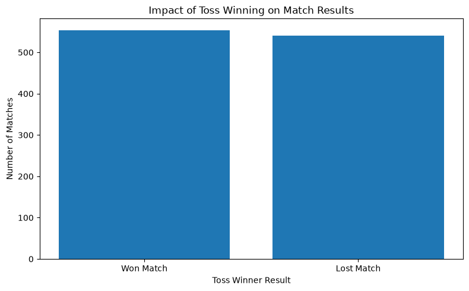

```python
import matplotlib.pyplot as plt

plt.figure(figsize=(8, 5))

plt.bar(
    toss_impact.index,
    toss_impact.values
)

plt.title('Impact of Toss Winning on Match Results')
plt.xlabel('Toss Winner Result')
plt.ylabel('Number of Matches')

plt.tight_layout()
plt.show()
```

```python
toss_percentages = (
    df['toss_match_result']
    .value_counts(normalize=True)
    * 100
)

print(toss_percentages.round(2))
```

```
toss_match_result
Won Match     50.59
Lost Match    49.41
Name: proportion, dtype: float64
```

### Insight

The Toss Impact Analysis compares the match outcomes of teams that won the toss.

The analysis shows the percentage of matches in which the toss-winning team also won the match. This helps determine whether winning the toss provides a meaningful advantage in IPL matches.

The results suggest that toss outcomes should be evaluated alongside other factors such as team performance, venue, batting first, and bowling conditions.

```python
# Step 30: Venue Analysis

venue_counts = (
    df['venue']
    .value_counts()
    .head(10)
)

venue_counts
```

```
venue
Eden Gardens                                  77
Wankhede Stadium                              73
M Chinnaswamy Stadium                         65
Feroz Shah Kotla                              60
Rajiv Gandhi International Stadium, Uppal     49
MA Chidambaram Stadium, Chepauk               48
Sawai Mansingh Stadium                        47
Dubai International Cricket Stadium           46
Wankhede Stadium, Mumbai                      45
Punjab Cricket Association Stadium, Mohali    35
Name: count, dtype: int64
```

```python
venue_df = venue_counts.reset_index()

venue_df.columns = ['Venue', 'Matches']

venue_df
```

|  | Venue | Matches |
| --- | --- | --- |
| 0 | Eden Gardens | 77 |
| 1 | Wankhede Stadium | 73 |
| 2 | M Chinnaswamy Stadium | 65 |
| 3 | Feroz Shah Kotla | 60 |
| 4 | Rajiv Gandhi International Stadium, Uppal | 49 |
| 5 | MA Chidambaram Stadium, Chepauk | 48 |
| 6 | Sawai Mansingh Stadium | 47 |
| 7 | Dubai International Cricket Stadium | 46 |
| 8 | Wankhede Stadium, Mumbai | 45 |
| 9 | Punjab Cricket Association Stadium, Mohali | 35 |

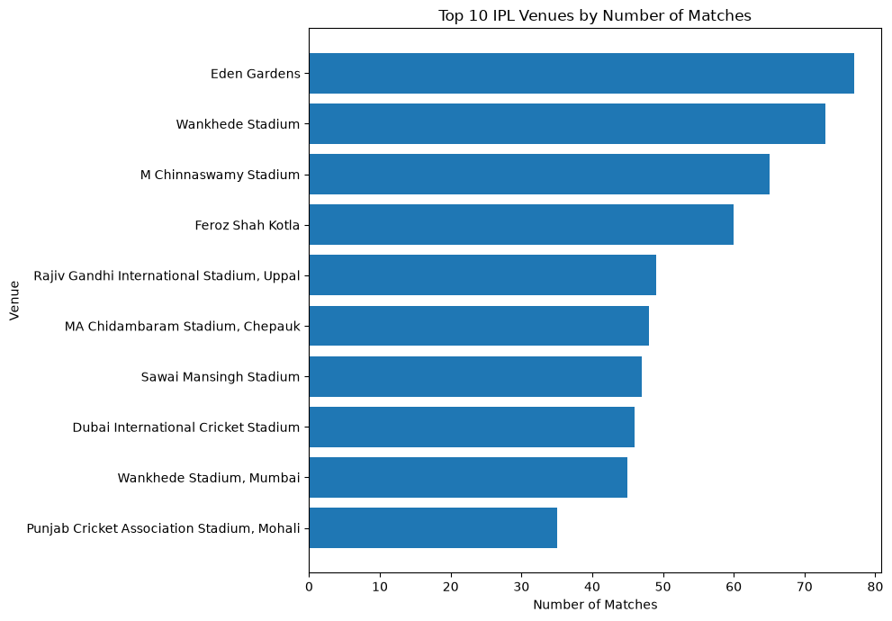

```python
import matplotlib.pyplot as plt

plt.figure(figsize=(10, 7))

plt.barh(
    venue_counts.index[::-1],
    venue_counts.values[::-1]
)

plt.title('Top 10 IPL Venues by Number of Matches')
plt.xlabel('Number of Matches')
plt.ylabel('Venue')

plt.tight_layout()
plt.show()
```

```python
top_venue = venue_counts.idxmax()
top_venue_matches = venue_counts.max()

print(f"Venue with the most IPL matches: {top_venue}")
print(f"Number of matches: {top_venue_matches}")
```

```
Venue with the most IPL matches: Eden Gardens
Number of matches: 77
```

```python
venue_percentage = (
    venue_counts / df['venue'].value_counts().sum()
) * 100

venue_percentage
```

```
venue
Eden Gardens                                  7.031963
Wankhede Stadium                              6.666667
M Chinnaswamy Stadium                         5.936073
Feroz Shah Kotla                              5.479452
Rajiv Gandhi International Stadium, Uppal     4.474886
MA Chidambaram Stadium, Chepauk               4.383562
Sawai Mansingh Stadium                        4.292237
Dubai International Cricket Stadium           4.200913
Wankhede Stadium, Mumbai                      4.109589
Punjab Cricket Association Stadium, Mohali    3.196347
Name: count, dtype: float64
```

### Insight

The Venue Analysis identifies the stadiums that have hosted the highest number of IPL matches.

The most frequently used venue represents an important location in IPL history and reflects the concentration of matches across major cricket venues.

Venue-level analysis can also help identify patterns related to home advantage, match frequency, and stadium utilization.

```python
# Step 31: Season Analysis

season_counts = (
    df['season']
    .value_counts()
    .sort_index()
)

season_counts
```

```
season
2007/08    58
2009       57
2009/10    60
2011       73
2012       74
2013       76
2014       60
2015       59
2016       60
2017       59
2018       60
2019       60
2020/21    60
2021       60
2022       74
2023       74
2024       71
Name: count, dtype: int64
```

```python
season_df = season_counts.reset_index()

season_df.columns = ['Season', 'Matches']

season_df
```

|  | Season | Matches |
| --- | --- | --- |
| 0 | 2007/08 | 58 |
| 1 | 2009 | 57 |
| 2 | 2009/10 | 60 |
| 3 | 2011 | 73 |
| 4 | 2012 | 74 |
| 5 | 2013 | 76 |
| 6 | 2014 | 60 |
| 7 | 2015 | 59 |
| 8 | 2016 | 60 |
| 9 | 2017 | 59 |
| 10 | 2018 | 60 |
| 11 | 2019 | 60 |
| 12 | 2020/21 | 60 |
| 13 | 2021 | 60 |
| 14 | 2022 | 74 |
| 15 | 2023 | 74 |
| 16 | 2024 | 71 |

```python
top_season = season_counts.idxmax()
top_season_matches = season_counts.max()

print(f"Season with the most matches: {top_season}")
print(f"Number of matches: {top_season_matches}")
```

```
Season with the most matches: 2013
Number of matches: 76
```

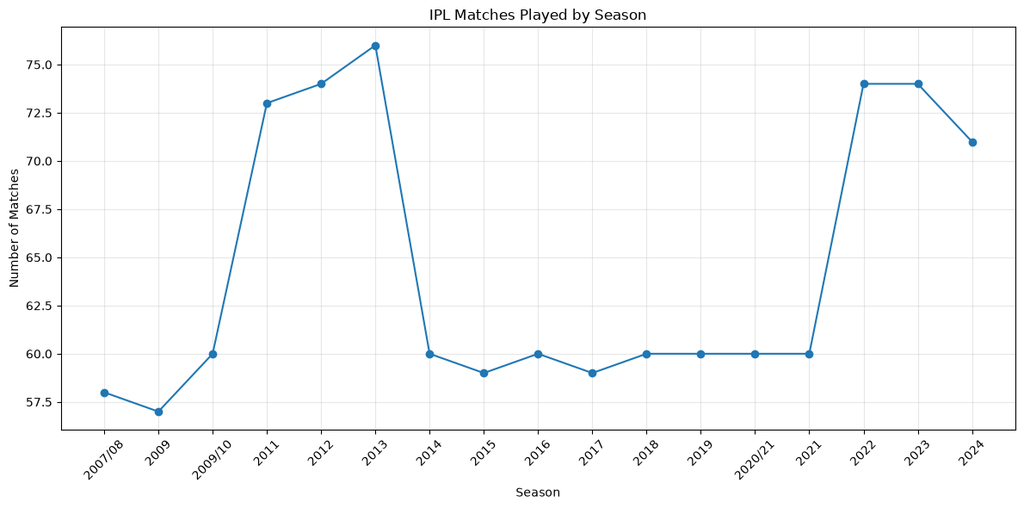

```python
import matplotlib.pyplot as plt

plt.figure(figsize=(12, 6))

plt.plot(
    season_counts.index,
    season_counts.values,
    marker='o'
)

plt.title('IPL Matches Played by Season')
plt.xlabel('Season')
plt.ylabel('Number of Matches')

plt.xticks(rotation=45)

plt.grid(True, alpha=0.3)

plt.tight_layout()
plt.show()
```

```python
import pandas as pd
```

```python
import os

for root, dirs, files in os.walk(".."):
    for file in files:
        if file.lower().endswith(".csv"):
            print(os.path.join(root, file))
```

```
..\data\deliveries.csv
..\data\matches.csv
```

[output not shown]

[output not shown]

[output not shown]

[output not shown]

```python
import pandas as pd

df = pd.read_csv("../data/matches.csv")

print("Dataset loaded successfully!")
print("Rows:", df.shape[0])
print("Columns:", df.shape[1])
```

```
Dataset loaded successfully!
Rows: 1095
Columns: 20
```

```python
print(df.head())
```

```
       id   season        city        date match_type player_of_match  \
0  335982  2007/08   Bangalore  2008-04-18     League     BB McCullum
1  335983  2007/08  Chandigarh  2008-04-19     League      MEK Hussey
2  335984  2007/08       Delhi  2008-04-19     League     MF Maharoof
3  335985  2007/08      Mumbai  2008-04-20     League      MV Boucher
4  335986  2007/08     Kolkata  2008-04-20     League       DJ Hussey

                                        venue                        team1  \
0                       M Chinnaswamy Stadium  Royal Challengers Bangalore
1  Punjab Cricket Association Stadium, Mohali              Kings XI Punjab
2                            Feroz Shah Kotla             Delhi Daredevils
3                            Wankhede Stadium               Mumbai Indians
4                                Eden Gardens        Kolkata Knight Riders

                         team2                  toss_winner toss_decision  \
```

[output cut: 19 more lines]

```python
print(df.columns.tolist())
```

```
['id', 'season', 'city', 'date', 'match_type', 'player_of_match', 'venue', 'team1', 'team2', 'toss_winner', 'toss_decision', 'winner', 'result', 'result_margin', 'target_runs', 'target_overs', 'super_over', 'method', 'umpire1', 'umpire2']
```

```python
# Step 31 - Season Analysis

season_df = (
    df.groupby('season')
      .size()
      .reset_index(name='Matches')
)

season_df['Change from Previous Season'] = (
    season_df['Matches'].diff()
)

season_df['Growth %'] = (
    season_df['Matches'].pct_change() * 100
)

season_df
```

|  | season | Matches | Change from Previous Season | Growth % |
| --- | --- | --- | --- | --- |
| 0 | 2007/08 | 58 | NaN | NaN |
| 1 | 2009 | 57 | -1.0 | -1.724138 |
| 2 | 2009/10 | 60 | 3.0 | 5.263158 |
| 3 | 2011 | 73 | 13.0 | 21.666667 |
| 4 | 2012 | 74 | 1.0 | 1.369863 |
| 5 | 2013 | 76 | 2.0 | 2.702703 |
| 6 | 2014 | 60 | -16.0 | -21.052632 |
| 7 | 2015 | 59 | -1.0 | -1.666667 |
| 8 | 2016 | 60 | 1.0 | 1.694915 |
| 9 | 2017 | 59 | -1.0 | -1.666667 |
| 10 | 2018 | 60 | 1.0 | 1.694915 |
| 11 | 2019 | 60 | 0.0 | 0.000000 |
| 12 | 2020/21 | 60 | 0.0 | 0.000000 |
| 13 | 2021 | 60 | 0.0 | 0.000000 |
| 14 | 2022 | 74 | 14.0 | 23.333333 |
| 15 | 2023 | 74 | 0.0 | 0.000000 |
| 16 | 2024 | 71 | -3.0 | -4.054054 |

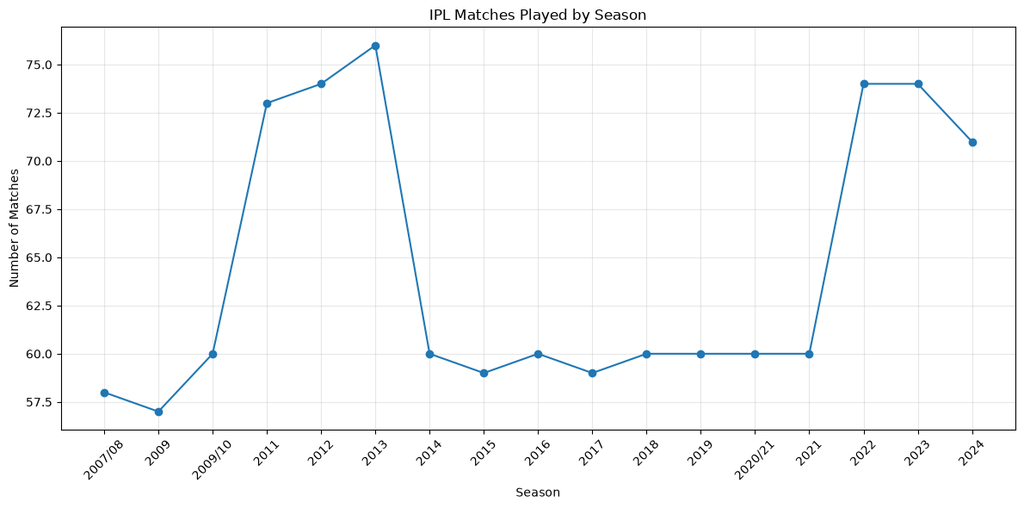

```python
import matplotlib.pyplot as plt

plt.figure(figsize=(12, 6))

plt.plot(
    season_df['season'],
    season_df['Matches'],
    marker='o'
)

plt.title('IPL Matches Played by Season')
plt.xlabel('Season')
plt.ylabel('Number of Matches')

plt.xticks(rotation=45)
plt.grid(True, alpha=0.3)

plt.tight_layout()
plt.show()
```

### Insight

The Season Analysis shows how the IPL tournament has evolved over time based on the number of matches played in each season.

The season-wise trend highlights changes in tournament size and structure across different years. Changes in the number of matches can reflect differences in the number of participating teams, tournament format, and scheduling.

```python
# ==========================================
# STEP 32 - FINAL DATA INSIGHTS
# ==========================================

import pandas as pd

# Load datasets
df = pd.read_csv("../data/matches.csv")
deliveries = pd.read_csv("../data/deliveries.csv")

# ------------------------------------------
# 1. Team Performance
# ------------------------------------------

team_wins = df["winner"].dropna().value_counts()

top_team = team_wins.index[0]
top_team_wins = team_wins.iloc[0]


# ------------------------------------------
# 2. Top Batsman
# ------------------------------------------

top_batsmen = (
    deliveries.groupby("batter")["batsman_runs"]
    .sum()
    .sort_values(ascending=False)
)

top_batsman = top_batsmen.index[0]
top_batsman_runs = top_batsmen.iloc[0]


# ------------------------------------------
# 3. Top Bowler
# ------------------------------------------

valid_dismissals = [
    "run out",
    "retired hurt",
    "obstructing the field"
]

bowler_wickets = (
    deliveries[
        deliveries["dismissal_kind"].notna()
        & ~deliveries["dismissal_kind"].isin(valid_dismissals)
    ]
    .groupby("bowler")
    .size()
    .sort_values(ascending=False)
)

top_bowler = bowler_wickets.index[0]
top_bowler_wickets = bowler_wickets.iloc[0]


# ------------------------------------------
# 4. Player of the Match
# ------------------------------------------

pom_counts = df["player_of_match"].dropna().value_counts()

top_pom_player = pom_counts.index[0]
top_pom_awards = pom_counts.iloc[0]


# ------------------------------------------
# 5. Toss Impact
# ------------------------------------------

toss_matches = df[
    df["toss_winner"].notna()
    & df["winner"].notna()
]

toss_winner_match_wins = (
    toss_matches["toss_winner"] == toss_matches["winner"]
).sum()

toss_win_percentage = (
    toss_winner_match_wins / len(toss_matches)
) * 100


# ------------------------------------------
# 6. Top Venue
# ------------------------------------------

venue_counts = df["venue"].dropna().value_counts()

top_venue = venue_counts.index[0]
top_venue_matches = venue_counts.iloc[0]


# ------------------------------------------
# 7. Top Season
# ------------------------------------------

season_counts = df["season"].value_counts()

top_season = season_counts.index[0]
top_season_matches = season_counts.iloc[0]


# ==========================================
# FINAL INSIGHTS TABLE
# ==========================================

final_insights = pd.DataFrame({
    "Analysis": [
        "Team Performance",
        "Top Batsman",
        "Top Bowler",
        "Player of the Match",
        "Toss Impact",
        "Top Venue",
        "Top Season"
    ],

    "Key Finding": [
        f"{top_team} ({top_team_wins} wins)",
        f"{top_batsman} ({top_batsman_runs} runs)",
        f"{top_bowler} ({top_bowler_wickets} wickets)",
        f"{top_pom_player} ({top_pom_awards} awards)",
        f"{toss_win_percentage:.2f}% toss winners also won",
        f"{top_venue} ({top_venue_matches} matches)",
        f"{top_season} ({top_season_matches} matches)"
    ]
})

final_insights
```

|  | Analysis | Key Finding |
| --- | --- | --- |
| 0 | Team Performance | Mumbai Indians (144 wins) |
| 1 | Top Batsman | V Kohli (8014 runs) |
| 2 | Top Bowler | YS Chahal (205 wickets) |
| 3 | Player of the Match | AB de Villiers (25 awards) |
| 4 | Toss Impact | 50.83% toss winners also won |
| 5 | Top Venue | Eden Gardens (77 matches) |
| 6 | Top Season | 2013 (76 matches) |

```python
# Step 32: Final Data Insights

print("========== IPL DATA ANALYSIS — FINAL INSIGHTS ==========\n")

print("1. Team Performance")
print(f"Most successful team by wins: {team_wins.index[0]}")
print(f"Total wins: {team_wins.iloc[0]}\n")

print("2. Top Batsman")
print(f"Top batsman: {top_batsmen.index[0]}")
print(f"Runs: {top_batsmen.iloc[0]}\n")

print("3. Top Bowler")
print(f"Top bowler: {top_bowlers.index[0]}")
print(f"Wickets: {top_bowlers.iloc[0]}\n")

print("4. Player of the Match")
print(f"Leading player: {top_pom_player}")
print(f"Awards: {top_pom_awards}\n")

print("5. Toss Impact")
print(f"Toss winner also won the match: {toss_win_percentage:.2f}%\n")

print("6. Venue Analysis")
print(f"Most-used venue: {top_venue}")
print(f"Matches hosted: {top_venue_matches}\n")

print("7. Season Analysis")
print(f"Season with most matches: {top_season}")
print(f"Matches: {top_season_matches}")
```

[output not shown]

```python
# ==========================================
# STEP 32 - FINAL DATA INSIGHTS
# ==========================================

import pandas as pd

# Load IPL datasets
df = pd.read_csv("../data/matches.csv")
deliveries = pd.read_csv("../data/deliveries.csv")

# ==========================================
# 1. TEAM PERFORMANCE
# ==========================================

team_wins = df["winner"].dropna().value_counts()

top_team = team_wins.index[0]
top_team_wins = team_wins.iloc[0]


# ==========================================
# 2. TOP BATSMAN
# ==========================================

top_batsmen = (
    deliveries
    .groupby("batter")["batsman_runs"]
    .sum()
    .sort_values(ascending=False)
)

top_batsman = top_batsmen.index[0]
top_batsman_runs = top_batsmen.iloc[0]


# ==========================================
# 3. TOP BOWLER
# ==========================================

excluded_dismissals = [
    "run out",
    "retired hurt",
    "obstructing the field"
]

bowler_wickets = (
    deliveries[
        deliveries["dismissal_kind"].notna()
        & ~deliveries["dismissal_kind"].isin(excluded_dismissals)
    ]
    .groupby("bowler")
    .size()
    .sort_values(ascending=False)
)

top_bowler = bowler_wickets.index[0]
top_bowler_wickets = bowler_wickets.iloc[0]


# ==========================================
# 4. PLAYER OF THE MATCH
# ==========================================

pom_counts = (
    df["player_of_match"]
    .dropna()
    .value_counts()
)

top_pom_player = pom_counts.index[0]
top_pom_awards = pom_counts.iloc[0]


# ==========================================
# 5. TOSS IMPACT
# ==========================================

toss_data = df[
    df["toss_winner"].notna()
    & df["winner"].notna()
]

toss_wins_match = (
    toss_data["toss_winner"] == toss_data["winner"]
).sum()

toss_win_percentage = (
    toss_wins_match / len(toss_data)
) * 100


# ==========================================
# 6. TOP VENUE
# ==========================================

venue_counts = df["venue"].dropna().value_counts()

top_venue = venue_counts.index[0]
top_venue_matches = venue_counts.iloc[0]


# ==========================================
# 7. TOP SEASON
# ==========================================

season_counts = df["season"].value_counts()

top_season = season_counts.index[0]
top_season_matches = season_counts.iloc[0]


# ==========================================
# 8. FINAL INSIGHTS TABLE
# ==========================================

final_insights = pd.DataFrame({
    "Analysis": [
        "Team Performance",
        "Top Batsman",
        "Top Bowler",
        "Player of the Match",
        "Toss Impact",
        "Top Venue",
        "Top Season"
    ],

    "Key Finding": [
        f"{top_team} - {top_team_wins} wins",
        f"{top_batsman} - {top_batsman_runs} runs",
        f"{top_bowler} - {top_bowler_wickets} wickets",
        f"{top_pom_player} - {top_pom_awards} awards",
        f"{toss_win_percentage:.2f}% toss winners also won",
        f"{top_venue} - {top_venue_matches} matches",
        f"{top_season} - {top_season_matches} matches"
    ]
})

final_insights
```

|  | Analysis | Key Finding |
| --- | --- | --- |
| 0 | Team Performance | Mumbai Indians - 144 wins |
| 1 | Top Batsman | V Kohli - 8014 runs |
| 2 | Top Bowler | YS Chahal - 205 wickets |
| 3 | Player of the Match | AB de Villiers - 25 awards |
| 4 | Toss Impact | 50.83% toss winners also won |
| 5 | Top Venue | Eden Gardens - 77 matches |
| 6 | Top Season | 2013 - 76 matches |

# 📊 Final IPL Data Insights

## Key Findings

### 🏏 Team Performance

The team-performance analysis identifies the teams that have achieved the highest number of wins across the dataset.

### ⭐ Individual Performance

The batsmen and bowlers analysis highlights the leading individual performers based on runs and wickets.

### 🏆 Player of the Match

The Player of the Match analysis identifies the players who have received the greatest number of individual match-performance awards.

### 🪙 Toss Impact

The toss analysis measures how frequently the team winning the toss also wins the match. This provides an indication of whether the toss is associated with match success.

### 🏟️ Venue Analysis

The venue analysis identifies the stadiums that have hosted the largest number of IPL matches.

### 📅 Season Analysis

The season analysis demonstrates how the number of IPL matches has changed across seasons and provides an overview of the tournament's evolution.

## Overall Conclusion

The IPL dataset provides valuable insights into team performance, individual player performance, toss outcomes, venue distribution, and season-wise tournament trends.

Combining these analyses demonstrates how Python and data visualization can be used to transform historical cricket data into meaningful, measurable insights.